# Homework #1

**See Canvas for the due date of this assignment**. Complete all of the following problems. Ideally, the theoretical problems should be answered in a Markdown cell directly underneath the question. If you don't know LaTex/Markdown, you may submit separate handwritten solutions to the theoretical problems, but please see the class [scanning policy](https://docs.google.com/document/d/1d_7PJvTGtMGtHWq8BezaTzYI5aYZkFgmchV_hTId6Ks/edit?usp=sharing). Please do not turn in messy work. Computational problems should be completed in this notebook (using the R kernel). Computational questions may require code, plots, analysis, interpretation, etc. Working in small groups is allowed, but it is important that you make an effort to master the material and hand in your own work.

```r
library(testthat)
```

## A. Theoretical Problems

### A.1: Connections between linear algebra and statistics

Let $\mathbf{a} = (a_1,...,a_n)^T$ and $\mathbf{y} = (y_1,...,y_n)^T$ be two vectors. Define the *inner product* of $\mathbf{a}$ and $\mathbf{y}$ to be $\mathbf{a}^T\mathbf{y} = a_1y_1 + a_2y_2 + ... + a_ny_n$.

**A.1 (a) [5 points] Interpret $\mathbf{y}$ as a set of observations of a variable. Find $\mathbf{a}$ such that $\mathbf{a}^T\mathbf{y}$ is equal to the sample mean of $\mathbf{y}$, i.e., $\bar{y}$.**

Definition of $\bar{y}$ is $$ \bar{y} = \frac{1}{n}\sum_{i=1}^n y_i $$ Therefore $\mathbf{a}^T$ has to be $$ \mathbf{a}^T = (\frac{1}{n}, \frac{1}{n}, \cdot\cdot\cdot, \frac{1}{n}) \\ \mathbf{\bar{y}} = \mathbf{a}^T \sum^n_{i=1}\mathbf{y} $$

Recall that the sample variance of data $\mathbf{y} = (y_1,...,y_n)^T$ is defined as

\begin{align*} s_y^2 = \frac{1}{n-1}\sum^n_{i=1}\left(y_i - \bar{y} \right)^2 \end{align*}

**A.1 (b) [7 points] Define $\mathbf{\bar{y}} = (\bar{y},..., \bar{y})^T$ (that is, $\mathbf{\bar{y}}$ is a vector where every entry is the sample mean of $\mathbf{y}$). Show that $(\mathbf{y} - \mathbf{\bar{y}})^T(\mathbf{y} - \mathbf{\bar{y}}) = (n-1)s_y^2$**

### A.2 Linear regression with matrices and vectors

**This problem might require some outside-of-class research if you haven't taken a linear algebra/matrix methods course.**

Matrices and vectors will play an important role for us in linear regression. Let's review some matrix theory as it might relate to linear regression.

Consider the system of linear equations

\begin{equation} Y_i = \beta_0 + \sum^p_{j=1}\beta_j x_{i,j} + \varepsilon_i, \end{equation}

for $i = 1,...,n$, where $n$ is the number of data points (measurements in the sample), and $j = 1,...,p$, where

1. $p+1$ is the number of parameters in the model.
2. $Y_i$ is the $i^{th}$ measurement of the *response variable*.
3. $x_{i,j}$ is the $i^{th}$ measurement of the $j^{th}$ *predictor variable*.
4. $\varepsilon_i$ is the $i^{th}$ *error term* and is a random variable, often assumed to be $N(0, \sigma^2)$.
5. $\beta_j$, $j = 0,...,p$ are *unknown parameters* of the model. We hope to estimate these, which would help us characterize the relationship between the predictors and response.

**A.2.(a) [5 points] Write the equation above in matrix vector form. Call the matrix including the predictors $X$, the vector of $Y_i$s $\mathbf{Y}$, the vector of parameters $\mathbf{\beta}$, and the vector of error terms $\mathbf{\varepsilon}$. (This is more LaTeX practice than anything else...)**

$$ \begin{bmatrix} y_1 \\ y_2 \\ \vdots \\ y_n \end{bmatrix} = \begin{bmatrix} 1 & x_{1,1} & x_{1,2} & \cdots & x_{1,j} \\ 1 & x_{2,1} & x_{2,2} & \cdots & x_{2,j} \\ \vdots & \vdots & \vdots & \ddots & \vdots \\ 1 & x_{n,1} & x_{n,2} & \cdots & x_{n,j} \\ \end{bmatrix} \begin{bmatrix} \beta_0 \\ \beta_1 \\ \vdots \\ \beta_j \end{bmatrix} + \begin{bmatrix} \epsilon_1 \\ \epsilon_2 \\ \vdots \\ \epsilon_n \\ \end{bmatrix} $$

**A.2.(b) [8 points] In class, we will find that the OLS estimator for $\mathbf{\beta}$ in MLR is $\widehat{\boldsymbol\beta} = (X^TX)^{-1}X^T\mathbf{Y}$.**

1. What condition must be true about the columns of $X$ for the "Gram" matrix $X^TX$ to be invertible?
2. What does this condition mean in practical terms?
3. Suppose that the number of measurements ($n$) is less than the number of model parameters ($p+1$). What does this say about the invertibility of $X^TX$? What does this mean on a practical level?
4. What is true about about $\widehat{\boldsymbol\beta}$ if $X^TX$ is not invertible?

$1) X^T$ and $X$ have to be independent columns for the "Gram" matrix to be invertible.

$2)$ The predictos are linearly independent of each other

$3)$ Infinite amout of solutions. Practically there are fewer equations than variables therefore a variable will take any value at one point.

$4)$ Folling from above that means $\hat{B}$ is undefined becuase $X^T X$ does not exist.

### A.3 More linear algebra and regression!

In class, we defined the *hat* or *projection* matrix as

$$H = X(X^TX)^{-1}X^T.$$

The goal of this question is to use the hat matrix to prove that the fitted values, $\widehat{\mathbf Y}$, and the residuals, $\widehat{\boldsymbol\varepsilon}$, are uncorrelated. We will do it in steps, and *some* of the proofs will only be required for STAT 5010 students. Note that STAT 4010 students are asked to answer part (e), as to why this result has practical importance.

**A.3 (a) [8 points] Show that $\widehat{Y} = HY$. That is, $H$ "puts a hat on" $Y$.**

$Y = X \cdot \beta + \epsilon$ and $\hat{\beta} = (X^T X)^{-1} X^T Y $ because of minimizing RSS: So, $$ \hat{Y} = X \hat{\beta} \\ = X(X^T X)^{-1}X^TY \\ = HY \\ \hat{Y} = HY $$

**A.3 (b) [9 points] Show that $H$ is symmetric: $H = H^T$.**

$$ H^T = (X(X^TX)^{-1}X^T)^T \\ \Rightarrow X^T(X^TX)^{-1T}X \\ \Rightarrow X^T(XX^T)^{-1}X \\ \Rightarrow X(X^TX)^{-1}X^T $$

**A.3 (c) (STAT 5010 Only) [4 points] Show that $H(I_n - H) = 0_n$, where $0_n$ is the zero matrix of size $n \times n$.**

$$ H(I_n - H) \\ = HI_n - HH \\ = H - (X(X^TX)^{-1}X^T)(X(X^TX)^{-1}X^T) \\ = H - (X(X^TX)^{-1}X^TX(X^TX)^{-1}X^T) \\ = H - (X(X^TX)^{-1}X^T \\ = H - H = 0_n $$

**A.3 (d) (STAT 5010 Only) [4 points] Stating that $\widehat{\mathbf Y}$ is uncorrelated with $\widehat{\boldsymbol\varepsilon}$ is equivalent to showing that these vectors are orthogonal. That is, we need to show that their dot product is zero:**

$$ \widehat{\mathbf Y}^T\widehat{\boldsymbol\varepsilon} = 0.$$

**Prove this result.**

It's intersting to think about why uncorrelated, in this case, is equivalent to orthogonal. Extra credit if you can tell me why!

$$ \hat{Y}^T\hat{\epsilon} \\ = \hat{Y}^T(Y-\hat{Y}) \\ = \hat{Y}^T(Y - HY) \\ = \hat{Y}^TY - \hat{Y}^THY \\ = Y^THY - Y^THHY \\ = Y^THY - Y^THY \\ = 0 $$

**A.3 (e) (STAT 5010 Only) [2 points] Why is this result important in the practical use of linear regression?**

It is important in practical use to check if our data is correct and it allows us to more easily intepret the effect of one predictor without regard to another.

## B. Computational Problems

### B.1 Exploratory data analysis and basic regression

**B.1.(a) Load the "gala" dataset, and describe the variables.**

```r
gala = read.table("https://www.colorado.edu/amath/sites/default/files/attached-files/gala.txt", sep = "\t")
```

**B.1.(b) [8 points] Use ggplot() to explore the relationship between the Species variable (response) and Endemics, Elevation, Nearest, and Adjacent (predictor variables). You might do so by creating four separate scatter plots. Do these relationships look linear? Does the variability in Species change as a function of any of the predictors? Are there any outliers in any of the plots?**

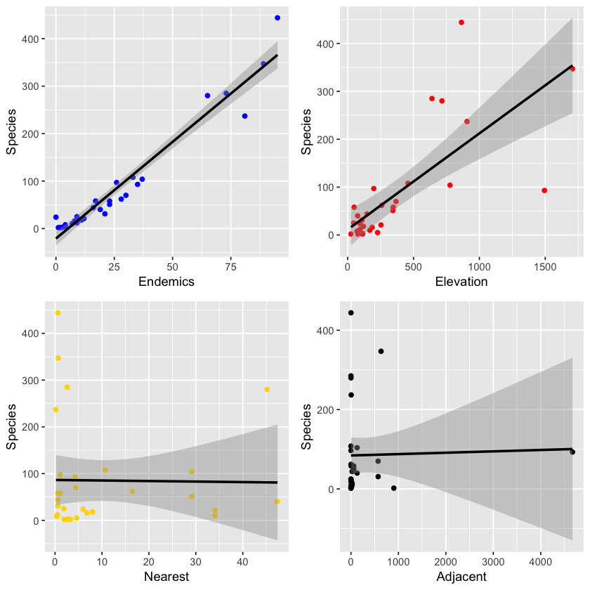

```r
library(ggplot2)
library(gridExtra)

p1 = ggplot(data=gala, aes(x = gala$Endemics, y =gala$Species)) + geom_point(color = "blue") + xlab("Endemics")+
ylab("Species") + stat_smooth(method = "lm", col = "black");

p2 = ggplot(data=gala, aes(x = gala$Elevation, y =gala$Species)) + geom_point(color = "red")+ xlab("Elevation")+
ylab("Species") + stat_smooth(method = "lm", col = "black");

p3 = ggplot(data=gala, aes(x = gala$Nearest, y =gala$Species)) + geom_point(color = "gold")+ xlab("Nearest")+
ylab("Species")+ stat_smooth(method = "lm", col = "black");

p4 = ggplot(data=gala, aes(x = gala$Adjacent, y =gala$Species)) + geom_point(color = "black")+ xlab("Adjacent")+
ylab("Species")+ stat_smooth(method = "lm", col = "black");
# Plotting all plots
grid.arrange(p1, p2,p3, p4, nrow=2, ncol=2)
```

From the resulting graphs, it appears that the variability in Species changes as we switch the function of predictors.

Adjacent and Elevation has outliers as the Adjacent and Elevation values increase.

**B.1.(c) [18 points] Perform a linear regression with Species as the response and Endemics, Elevation, Nearest, and Adjacent as predictors. Store your `lm()` object in the variable `lm_species`. Interpret the parameter estimate associated with Endemics in the markdown cell below (assume, for the moment, that the model is correct, and so the interpretation holds).**

```r
lm_species = lm(Species ~ Endemics + Elevation + Nearest + Adjacent , data = gala)
summary(lm_species)
```

```
Call:
lm(formula = Species ~ Endemics + Elevation + Nearest + Adjacent,
    data = gala)

Residuals:
    Min      1Q  Median      3Q     Max
-77.232 -10.318   3.412   9.521  70.768

Coefficients:
              Estimate Std. Error t value Pr(>|t|)
(Intercept) -17.510039   8.333335  -2.101   0.0459 *
Endemics      4.192551   0.429056   9.772  5.1e-10 ***
Elevation    -0.008594   0.032903  -0.261   0.7961
Nearest      -0.203743   0.376472  -0.541   0.5932
Adjacent     -0.005629   0.009876  -0.570   0.5738
---
Signif. codes:  0 ‘***’ 0.001 ‘**’ 0.01 ‘*’ 0.05 ‘.’ 0.1 ‘ ’ 1

Residual standard error: 28.59 on 25 degrees of freedom
Multiple R-squared:  0.9464,	Adjusted R-squared:  0.9378
F-statistic: 110.3 on 4 and 25 DF,  p-value: 1.673e-15
```

Looking at the table, first we see that the p-value is infitesimally small that mean that one of our predictors has a significant influence in the results of Species. Therefore, it seems that Endemics cause a significant change in Species base from the results of the t-value.

**B.1.(d) [16 points] Calculate the residual sum of squares, and the total sum of squares for this model, and store these quantities in `rss` and `tss`, respectively. Then, use these calculations to verify the Multiple R-squared calculation in the summary from the previous part. Store your $R^2$ for this model in `r2`. Interpret $R^2$ (assume, for the moment, that the model is correct, and so the interpretation holds). Note that the anova table calculates sums of squares. Why doesn't the total sum of squares show up in the table?**

```r
anovaLm =anova(lm_species)
tss = sum(anovaLm$`Sum Sq`);
rss = anovaLm[5,2]
r2 = 1 - rss/tss
```

The total sum of squares does not appear in the table becuase it is used to calculate the **mean sq** and **f-value**. From further research it is also insignificant since we want to focus more on the **mean sq**, **f-value**, or **R-squared**.

**B.1.(e) [8 points] Plot the residuals vs the fitted values. Based on what we've discussed in class, what do you expect to see in this plot? Do you see what you expect to see? If not, what does that mean?**

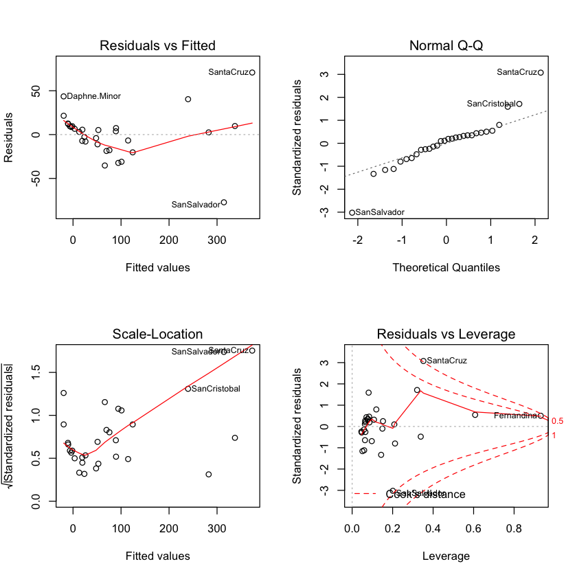

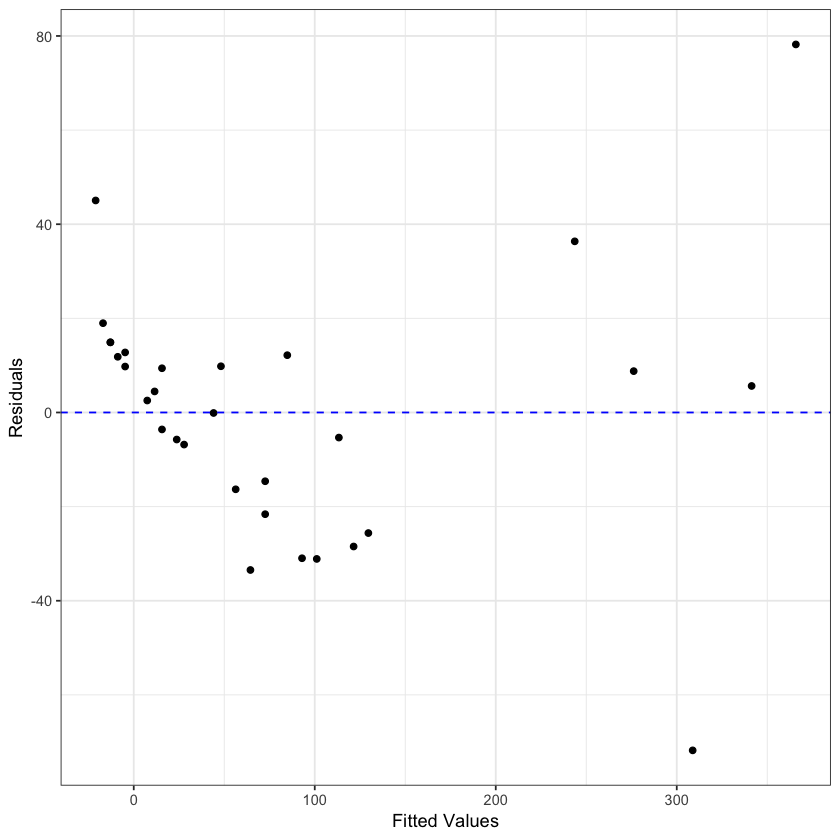

```r
library(gridExtra)
y = gala$Species

# Y = XB
par(mfrow = c(2,2))
plot(lm_species)

#Endemics
X = cbind(1, gala$Endemics)
beta1 = solve(t(X)%*%X)%*%t(X)%*%y
yHat = X%*%beta1 # fitted values
residuals = y - yHat # residuals





endemic = data.frame(yHat, residuals)

p2 = ggplot(endemic, aes(x = yHat, y = residuals)) + geom_point() +
    theme_bw() +
    geom_hline(yintercept=0, linetype="dashed", color = "blue") +
    ylab("Residuals") +
    xlab("Fitted Values")
p2
```